# QUEUE

## Definisi Queues

Queues atau antrian merupakan struktur data dimana penambahan data baru dan penghapusan data berada di ujung yang berbeda. Hal ini berbeda dengan stacks, dimana penambahan data baru dan penghapusan data, dilakukan pada ujung yang sama. Pada Queues, seperti halnya antrian, penambahan data baru dilakukan di suatu ujung atau yang dikenal dengan nama rear, dan penghapusan data dilakukan pada ujung yang dikenal dengan nama front, seperti yang terlihat pada Gambar 1 berikut :

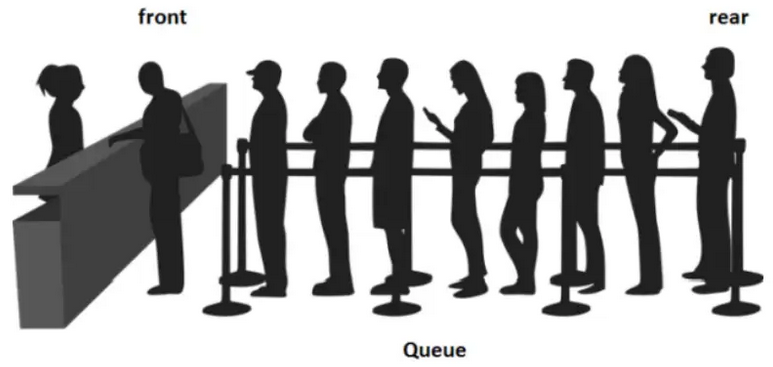

Suatu kumpulan barang yang diurutkan di mana penambahan barang baru terjadi di salah satu ujung, yang disebut "belakang," dan penghapusan barang yang sudah ada terjadi di ujung lainnya, yang umumnya disebut "depan." Prinsip pengurutan ini terkadang disebut FIFO, first-in first-out (masuk pertama keluar pertama). Ini juga dikenal sebagai "first-come first-served" (datang pertama dilayani pertama).  
Queue() membuat antrean baru yang kosong. Fungsi ini tidak memerlukan parameter dan mengembalikan antrean kosong.  
enqueue(item) menambahkan item baru ke bagian belakang antrean. Fungsi ini membutuhkan item tersebut dan tidak mengembalikan apa pun.  
dequeue() menghapus item terdepan dari antrean. Fungsi ini tidak memerlukan parameter dan mengembalikan item tersebut. Antrean dimodifikasi.  
isEmpty() memeriksa apakah antrean kosong. Fungsi ini tidak memerlukan parameter dan mengembalikan nilai boolean.  
size() mengembalikan jumlah item dalam antrean. Fungsi ini tidak memerlukan parameter dan mengembalikan bilangan bulat.

## Operasi pada Queues

Terdapat beberapa operasi dasar pada struktur data Queues ini, antara lain :

- queue (), inisialisasi struktur data queue kosong
- enqueue (data), penambahan *data* baru pada queue
- dequeue (), penghapusan data
- isEmpty(), pengecekan apakah queue dalam keadaan kosong
- size (), informasi jumlah data yang terdapat pada queue  
  Ilustrasi penambahan dan penghapusan data dapat dilihat pada Gambar 2 dan Gambar 3 berikut :

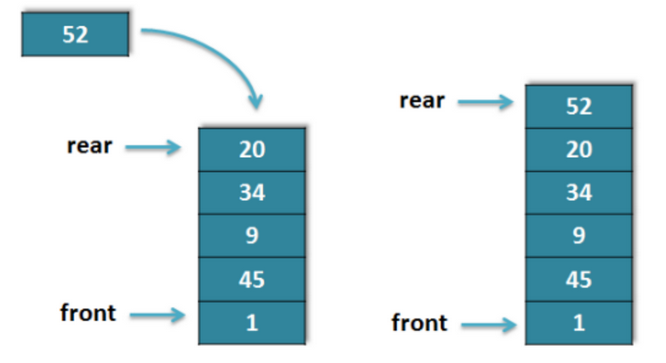

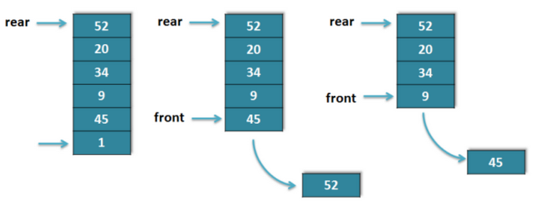

  Pada Gambar 2 ditunjukkan bahwa penambahan data baru (enqueue) dilakukan pada ujung data 'rear', sedangkan penghapusan data (dequeque) dilakukan pada ujung data 'front', karena sifat queues yang FIFO.  
  Implementasi queues dapat dilakukan pada tipe data lists. Data pada indeks terakhir pada list adalah merupakan data yang terletak pada ujung front pada queues. Sehingga proses dequeue dilakukan dengan menggunakan method pop pada list. Sedangkan data pada indeks awal, atau indeks ke-0 dari list, menunjukkan data yang terletak pada posisi rear dari queues. Oleh karena itu proses enqueue dilakukan dengan method insert pada posisi 0 dari list.  
  Misalkan terdapat data berbentuk list, sebagai berikut :  
  data=[8, 3, 9, 2]  
  Jika dilakukan data.insert(0,74) , atau penambahan data pada posisi rear, maka data akan berubah menjadi :  
  data=[74, 8, 3, 9, 2]  
  Jika dilakukan data.pop() , atau penghapusan data pada posisi front, maka data akan berubah menjadi :  
  data=[74, 8, 3, 9]

### Code

Berikut adalah code-code untuk pembentukan queues dan operasi-operasi yang terdapat pada queues

```python
def createQueue():
    q=[]
    return (q)
def enqueue(q,data):
    q.insert(0,data)
    return(q)
def dequeue(q):
    data=q.pop()
    return(data)
def isEmpty(q):
    return (q==[])
def size(q):
    return (len(q))
```

```python
q=createQueue()

enqueue(q,'matematika')
enqueue(q,'struktur data')
enqueue(q,'bahasa inggris')
enqueue(q,'pemrograman web')
print(q)
```

```
['pemrograman web', 'bahasa inggris', 'struktur data', 'matematika']
```

```python
temp=dequeue(q)
print(q)
print(temp)
```

```
['pemrograman web', 'bahasa inggris', 'struktur data']
matematika
```

```python
enqueue(q,dequeue(q))
print(q)
```

```
['struktur data', 'pemrograman web', 'bahasa inggris']
```

```python
a=dequeue(q)
print(a,q)
```

```
bahasa inggris ['struktur data', 'pemrograman web']
```

```python
enqueue(q,'new')
```

```
['new', 'struktur data', 'pemrograman web']
```

```python
isEmpty(q)
```

```
False
```

```python
size(q)
```

```
3
```

## Implementasi-Queues

Contoh implementasi queues ini adalah permainan anak-anak, yaitu permainan ular naga. Pada permainan ini, sekelompok anak berbaris dan dan terdapat dua buah anak sebagai penjaga, yang bertugas untuk 'menangkap anak' seiring dengan lagu 'ular naga' berakhir. Permainan ini akan berakhir jika hanya terdapat satu anak yang memenangkan permainan, yaitu anak tersebut lolos dari tangkapan penjaga, seperti yang terlihat pada Gambar 4

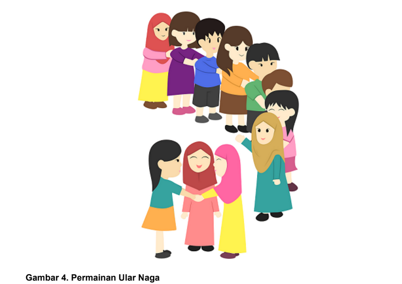

Berikut code simulasi dari permainan tersebut, dengan sedikit modifikasi, yaitu fungsi penjaga dan lagu 'ular naga' digantikan dengan bilangan tertentu, dan sekolompok anak disusun dalam suatu antrian. Permainan akan terus berjalan, sampai dengan hitungan bilangan tertentu tersebut. Jika pada hitungan tertentu, terdapat anak yang berada di ujung antrian (front), maka anak tersebut harus keluar barisan antrian. Permainan dimenangkan oleh seorang anak yang tersisa di dalam antrian.

```python
def ularNaga(nama, hitungan):
    gameQueue = createQueue()
    for namaAnak in nama:
        enqueue(gameQueue,namaAnak)
    print('Peserta Permainan=',gameQueue)
    while size(gameQueue) > 1:
        for i in range(hitungan):
            enqueue(gameQueue,dequeue(gameQueue))
            print('hitungan ke-',i,'=',gameQueue)
        dequeue(gameQueue)
        print('Peserta Permainan=',gameQueue)
    return dequeue(gameQueue)
```

```python
ularNaga(['andi','rita','sari','anton','rafa','diana','zaki'],2)
```

```
Peserta Permainan= ['zaki', 'diana', 'rafa', 'anton', 'sari', 'rita', 'andi']
hitungan ke- 0 = ['andi', 'zaki', 'diana', 'rafa', 'anton', 'sari', 'rita']
hitungan ke- 1 = ['rita', 'andi', 'zaki', 'diana', 'rafa', 'anton', 'sari']
Peserta Permainan= ['rita', 'andi', 'zaki', 'diana', 'rafa', 'anton']
hitungan ke- 0 = ['anton', 'rita', 'andi', 'zaki', 'diana', 'rafa']
hitungan ke- 1 = ['rafa', 'anton', 'rita', 'andi', 'zaki', 'diana']
Peserta Permainan= ['rafa', 'anton', 'rita', 'andi', 'zaki']
hitungan ke- 0 = ['zaki', 'rafa', 'anton', 'rita', 'andi']
hitungan ke- 1 = ['andi', 'zaki', 'rafa', 'anton', 'rita']
Peserta Permainan= ['andi', 'zaki', 'rafa', 'anton']
hitungan ke- 0 = ['anton', 'andi', 'zaki', 'rafa']
hitungan ke- 1 = ['rafa', 'anton', 'andi', 'zaki']
Peserta Permainan= ['rafa', 'anton', 'andi']
hitungan ke- 0 = ['andi', 'rafa', 'anton']
hitungan ke- 1 = ['anton', 'andi', 'rafa']
Peserta Permainan= ['anton', 'andi']
hitungan ke- 0 = ['andi', 'anton']
hitungan ke- 1 = ['anton', 'andi']
Peserta Permainan= ['anton']
```

```
'anton'
```